# Exercise 4.16 Seminar Challenge

Chicken Demand: Which Functional Form Tells the Best Story?

## The four models

Using the 52 annual observations in `newbroiler` for 1950–2001:

### 1. The reciprocal model

$$q=\alpha_1+\alpha_2\left(\frac{1}{p}\right)+e$$

### 3. Log-linear model

$$\ln(q)=\phi_1+\phi_2p+e$$

### 2. Linear-log model

$$q=\gamma_1+\gamma_2\ln(p)+e$$

### 4. Log-log Model

$$\ln(q)=\beta_1+\beta_2\ln(p)+e$$

`q` = per-capita chicken consumption, `p` = real price of chicken

## Seminar mission

For **each model**, the goal is to answer:

1. How do we estimate it in R?
2. What do the estimated coefficients mean?
3. What is the **marginal effect** of price?
4. What is the **price elasticity of demand**?

Then we compare all four models.

## Before touching R

**Q1.** What does economic theory suggests about the relationship between **q** and **p**?

**Expected answer**

Economic theory suggests: Higher chicken prices should reduce chicken consumption.

**Q2.** Predict the coefficient signs

- Model 1: $\alpha_2$ ?
- Model 2: $\gamma_2$ ?
- Model 3: $\phi_2$ ?
- Model 4: $\beta_2$ ?

Commit before the reveal.

## Reveal — expected signs

### Model 1

As $p$ rises, $1/p$ falls.

For $q$ to fall as $p$ rises:

$$\boxed{\alpha_2>0}$$

### Models 2 - 4

For downward-sloping demand:

$$\boxed{\gamma_2<0,\qquad \phi_2<0, \qquad \beta_2<0}$$

# Model 1 — Reciprocal

## problem 1 — Estimate Model 1

Estimate

$$q=\alpha_1+\alpha_2(1/p)+e.$$

### In R

Write the command yourself first.

## Solution 1 — R code

```r
# Model 1: reciprocal
m1 <- lm(q ~ I(1/p), data = newbroiler)
summary(m1)
```

```
Call:
lm(formula = q ~ I(1/p), data = newbroiler)

Residuals:
    Min      1Q  Median      3Q     Max
-9.9978 -2.7552 -0.1028  3.1299  9.1247

Coefficients:
            Estimate Std. Error t value Pr(>|t|)
(Intercept)   -6.024      2.059  -2.926  0.00516 **
I(1/p)        48.365      2.561  18.884  < 2e-16 ***
---
Signif. codes:  0 '***' 0.001 '**' 0.01 '*' 0.05 '.' 0.1 ' ' 1

Residual standard error: 4.245 on 50 degrees of freedom
Multiple R-squared:  0.877, Adjusted R-squared:  0.8746
F-statistic: 356.6 on 1 and 50 DF,  p-value: < 2.2e-16
```

Record:

$$\hat\alpha_1=\underline{\hspace{2cm}},\qquad
\hat\alpha_2=\underline{\hspace{2cm}},\qquad
se(\hat\alpha_1)=\underline{\hspace{2cm}},\qquad
se(\hat\alpha_2)=\underline{\hspace{2cm}},\qquad
R^2=\underline{\hspace{2cm}}$$

## problem 2 — Interpret Model 1

Your fitted equation is

$$\widehat q
=
-6.02+
48.36\left(\frac1p\right).$$

### questions

1. Does $\hat\alpha_2$ have the expected sign?
2. Does $\hat\alpha_2$ itself equal the effect of a $1 increase in $p$?
3. Why or why not?

## Solution 2

$\hat\alpha_2$ is the coefficient on

$$\frac1p,$$

not directly on $p$.

So $\hat\alpha_2$ itself is **not** the marginal effect of price.

To obtain the price effect, differentiate the fitted function with respect to $p$.

## problem 3 — Derive the marginal effect

For

$$q=\alpha_1+\alpha_2\left(\frac1p\right),$$

derive

$$\frac{dq}{dp}=?$$

## Solution 3 — Reciprocal marginal effect

Because

$$\frac{d}{dp}\left(\frac1p\right)
=-\frac1{p^2},$$

we obtain

$$\boxed{
\frac{dq}{dp}
=-\frac{\alpha_2}{p^2}
}$$

Estimated marginal effect:

$$\boxed{
\widehat{ME}_1(p)
=-\frac{\hat\alpha_2}{p^2}
}$$

## problem 4 — Marginal effect at the median price

Compute the marginal effect at the median price, and then interpret it in words.

## Solution 4 — R code

```r
p0 <- median(newbroiler$p) #1.31

a2 <- coef(m1)[2]
ME1 <- -a2 / p0^2
ME1
```

```
   I(1/p)
-28.20351
```

### Interpretation template

> At a real chicken price of $1.31, a $1 increase in real price is associated with approximately **_____ pounds** change in predicted per-capita consumption.

## problem 5 — Derive Model 1 elasticity

Recall:

$$\varepsilon
=
\frac{dq}{dp}\frac{p}{q}.$$

Use

$$\frac{dq}{dp}
=-\frac{\alpha_2}{p^2}$$

to derive the elasticity.

## Solution 5 — Reciprocal elasticity

$$\varepsilon_1
=
-\frac{\alpha_2}{p^2}\frac{p}{q}$$

so

$$\boxed{
\varepsilon_1
=-\frac{\alpha_2}{pq}
}$$

Using fitted quantity:

$$\boxed{
\hat\varepsilon_1(p)
=-\frac{\hat\alpha_2}{p\widehat q(p)}
}$$

## problem 6 — Compute Model 1 elasticity

Compute model 1 elasticity at the median price, and then classify demand as elastic or inelastic.

## Solution 6 — R code

```r
f <- mosaic::makeFun(m1)
#f(p0)

elas1 <- ME1 * p0 / f(p0)

 # put together
c(
  fitted_q = f(p0),
  marginal_effect = ME1,
  elasticity = elas1
)
```

```
            fitted_q.1 marginal_effect.I(1/p)      elasticity.I(1/p)
             30.908842             -28.203514              -1.194907
```

Classification:

- $|\hat\varepsilon|<1$: inelastic
- $|\hat\varepsilon|>1$: elastic

## Problem 7 — plot Model 1

Plot observed $q$ against $p$ and overlay the fitted reciprocal curve.

**Question:** Before running R, what shape do you expect?

## Solution 7 — R plot

**Show R code**

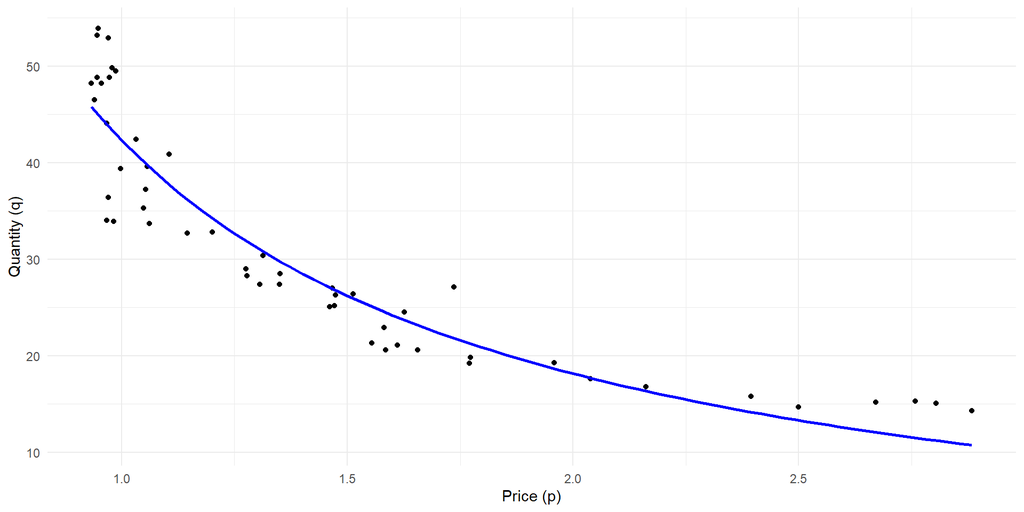

```r
newbroiler |>
  ggplot(aes(x = p, y = q)) +
  geom_point() +
  geom_smooth(
    method = "lm",
    formula = y ~ I(1/x),
    se = FALSE,
    color = "blue"
  ) +
  labs(x = "Price (p)", y = "Quantity (q)") +
  theme_minimal()
```

**Q:** How well does the fitted curve follow the data?

# Model 2 — Linear-log

## problem 8 — Estimate Model 2

Estimate

$$q=\gamma_1+\gamma_2\ln(p)+e.$$

Write the R command first.

## Solution 8 — R code

```r
# Model 2: linear-log
m2 <- lm(q ~ log(p), data = newbroiler)
summary(m2)
```

```
Call:
lm(formula = q ~ log(p), data = newbroiler)

Residuals:
   Min     1Q Median     3Q    Max
-8.286 -4.186 -1.747  3.818 11.006

Coefficients:
            Estimate Std. Error t value Pr(>|t|)
(Intercept)  41.2111     0.9898   41.63   <2e-16 ***
log(p)      -31.9078     2.1584  -14.78   <2e-16 ***
---
Signif. codes:  0 '***' 0.001 '**' 0.01 '*' 0.05 '.' 0.1 ' ' 1

Residual standard error: 5.223 on 50 degrees of freedom
Multiple R-squared:  0.8138,    Adjusted R-squared:  0.8101
F-statistic: 218.5 on 1 and 50 DF,  p-value: < 2.2e-16
```

$$\text {Record:} \space \space \hat\gamma_1=\underline{\hspace{2cm}},\qquad
\hat\gamma_2=\underline{\hspace{2cm}}$$

## problem 9 — Interpret $\hat\gamma_2$

Model 2 is

$$q=41.21-31.91\ln(p).$$

Which interpretation is closest?

A. A $1 increase in $p$ changes $q$ by $\gamma_2$ pounds.  
B. A 1% increase in $p$ changes $q$ by approximately $\gamma_2/100$ pounds.  
C. A 1% increase in $p$ changes $q$ by $\gamma_2$ percent.

## Solution 9

Correct answer: **B**

For the linear-log model,

$$\boxed{
1\%\text{ increase in }p
\Rightarrow
\frac{\gamma_2}{100}
\text{ unit change in }q
}$$

Demand theory suggests

$$\gamma_2<0.$$

## problem 10 — Derive Model 2 marginal effect

For

$$q=\gamma_1+\gamma_2\ln(p),$$

derive

$$\frac{dq}{dp}=?$$

## Solution 10

Because $\frac{d}{dp}(\ln p)=\frac1p,$

we obtain

$$\boxed{
\frac{dq}{dp}
=
\frac{\gamma_2}{p}
}$$

Estimated marginal effect:

$$\boxed{
\widehat{ME}_2(p)
=
\frac{\hat\gamma_2}{p}
}$$

## problem 11 — Compute Model 2 marginal effect

Compute the marginal effect at the median price, and then interprate the result in words.

## Solution 11 — R code

```r
g2 <- coef(m2)[2]
ME2 <- g2 / p0
ME2
```

```
   log(p)
-24.36593
```

### Interpretation

> At $p=1.31$, a $1 increase in real chicken price is associated with approximately **_____ pounds** change in predicted per-capita consumption.

## problem 12 — Derive Model 2 elasticity

Use

$$\varepsilon
=
\frac{dq}{dp}\frac{p}{q}$$

and

$$\frac{dq}{dp}=\frac{\gamma_2}{p}.$$

Simplify.

## Solution 12 — Linear-log elasticity

$$\varepsilon_2
=
\frac{\gamma_2}{p}\frac{p}{q}$$

therefore

$$\boxed{
\varepsilon_2
=
\frac{\gamma_2}{q}
}$$

Using fitted quantity:

$$\boxed{
\hat\varepsilon_2(p)
=
\frac{\hat\gamma_2}{\widehat q(p)}
}$$

## problem 13 — Compute Model 2 elasticity

Calculate the elasticiy at the median price and interprete the result in words.

## Solution 13 — R code

```r
f <- mosaic::makeFun(m2)

elas2 <- coef(m2)[2] /f(p0)
elas2
```

```
    log(p)
-0.9785646
```

**Compare:** Is this elasticity close to the reciprocal-model result?

## problem 14 — plot Model 2

Plot the fitted linear-log curve against the original $p$ values.

**Question:** Will the fitted relationship be a straight line when plotted against $p$?

## Solution 14 — R plot

**Show R code**

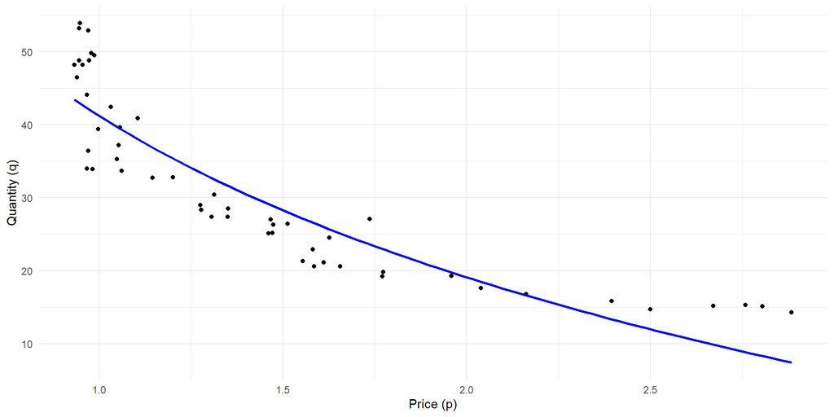

```r
newbroiler |>
  ggplot(aes(x = p, y = q)) +
  geom_point() +
  geom_smooth(
    method = "lm",
    formula = y ~ I(log(x)),
    se = FALSE,
    color = "blue"
  ) +
  labs(x = "Price (p)", y = "Quantity (q)") +
  theme_minimal()
```

It is linear in $\ln(p)$, not in $p$.

# Model 3 — Log-linear

## problem 15 — Estimate Model 3

Estimate

$$\ln(q)=\phi_1+\phi_2p+e.$$

Write the R command first.

## Solution 15 — R code

```r
# Model 3: log-linear
m3 <- lm(log(q) ~ p, data = newbroiler)
summary(m3)
```

```
Call:
lm(formula = log(q) ~ p, data = newbroiler)

Residuals:
     Min       1Q   Median       3Q      Max
-0.25251 -0.12407 -0.05208  0.14091  0.28644

Coefficients:
            Estimate Std. Error t value Pr(>|t|)
(Intercept)  4.33079    0.06323   68.50   <2e-16 ***
p           -0.66422    0.04078  -16.29   <2e-16 ***
---
Signif. codes:  0 '***' 0.001 '**' 0.01 '*' 0.05 '.' 0.1 ' ' 1

Residual standard error: 0.1599 on 50 degrees of freedom
Multiple R-squared:  0.8414,    Adjusted R-squared:  0.8382
F-statistic: 265.2 on 1 and 50 DF,  p-value: < 2.2e-16
```

$$\text{Record:} \space \space \hat\phi_1=\underline{\hspace{2cm}},\qquad
\hat\phi_2=\underline{\hspace{2cm}}$$

## problem 16 — Interpret $\hat\phi_2$

Model 3 is

$$\ln(q)=4.33-0.66 \space p$$

Which interpretation is closest?

A. A $1 increase in $p$ changes $q$ by $\phi_2$ pounds.  
B. A $1 increase in $p$ changes $q$ by approximately $100\phi_2$ percent.  
C. A 1% increase in $p$ changes $q$ by $\phi_2$ percent.

## Solution 16

Correct answer: **B**

For the log-linear model,

$$\boxed{
1\text{-unit increase in }p
\Rightarrow
\text{approximately }100\phi_2\%
\text{ change in }q
}$$

Demand theory suggests

$$\phi_2<0.$$

## problem 17 — Derive Model 3 marginal effect

For,

$$\ln(q)=\phi_1+\phi_2p+e.$$
drive,

$$\frac{dq}{dp}=?$$

## Solution 17

Since $d(ln q)=\frac{dq}{q},$ we can write

$$\boxed{
\frac{dq}{dp}=\phi_2q
}$$

Estimated marginal effect:

$$\boxed{
\widehat{ME}_3(p)
=
\hat\phi_2\widehat q(p)
}$$

## problem 18 — Compute Model 3 marginal effect

Compute the marginal effect at the median price and then interpret the result in words.

## Solution 18 — R code

```r
q <- mosaic::makeFun(m3)
ME3 <- coef(m3)[2]*q(p0)
ME3
```

```
        p
-21.15405
```

## problem 19 — Derive Model 3 elasticity

Use

$$\varepsilon
=
\frac{dq}{dp}\frac{p}{q}$$

and

$$\frac{dq}{dp}=\phi_2q.$$

Simplify.

## Solution 19 — Log-linear elasticity

$$\varepsilon_3
=
\phi_2q\frac{p}{q}$$

so

$$\boxed{
\varepsilon_3
=
\phi_2p
}$$

At $p=1.31$:

$$\boxed{
\hat\varepsilon_3
=
1.31\hat\phi_2
}$$

## problem 20 — Compute Model 3 elasticity

Calculate the elasticity at the median price.

Then classify demand as elastic or inelastic.

## Solution 20 — R code

```r
elas3 <-  p0*coef(m3)[2]
elas3
```

```
         p
-0.8698175
```

**Compare:** How close is this elasticity to Models 1 and 2?

## problem 21 — plot Model 3

plot the observed $q$ values and the fitted log-linear curve on the original $q$ scale.

## Solution 21 — R plot

**Show R code**

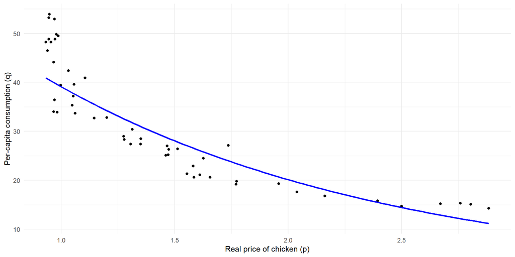

```r
newbroiler |>
  ggplot(aes(x = p, y = q)) +
  geom_point() +
  stat_function(
    fun = function(p) exp(
      predict(m3, newdata = data.frame(p = p))
    ),
    color = "blue",
    linewidth = 1
  ) +
  labs(
    x = "Real price of chicken (p)",
    y = "Per-capita consumption (q)"
  ) +
  theme_minimal()
```

### Discuss

Does the fitted curve capture the data better or worse than Models 1 and 2?

# Compare the models

## problem 22 — Marginal-effect table

Complete from memory.

| Model | Marginal effect $dq/dp$ |
| --- | --- |
| Reciprocal | ? |
| Linear-log | ? |
| Log-linear | ? |

## Solution 22

| Model | Marginal effect |
| --- | --- |
| Reciprocal | $-\alpha_2/p^2$ |
| Linear-log | $\gamma_2/p$ |
| Log-linear | $\phi_2q$ |

### Main lesson

The marginal effect changes with the point of evaluation in all three models.

## problem 23 — Elasticity table

Complete from memory.

| Model | Elasticity |
| --- | --- |
| Reciprocal | ? |
| Linear-log | ? |
| Log-linear | ? |

## Solution 23

| Model | Elasticity |
| --- | --- |
| Reciprocal | $-\alpha_2/(pq)$ |
| Linear-log | $\gamma_2/q$ |
| Log-linear | $\phi_2p$ |

Evaluate all three at the median price, and the corresponding fitted quantity.

## problem 24 — Build one comparison table in R

Create one table containing, at median price:

- fitted $q$;
- marginal effect;
- elasticity.

for Models 1–3.

## Solution 24 — R code

**Show R code**

```r
p0 <- median(newbroiler$p, na.rm = TRUE)

qhat1 <- predict(m1, newdata = data.frame(p = p0))

qhat2 <- predict(m2, newdata = data.frame(p = p0))

qhat3 <- exp(predict(m3, newdata = data.frame(p = p0)))


comparison <- data.frame(
  Model = c(
    "Reciprocal",
     "Linear-log",
     "Log-linear"
   ),
   Fitted_q = c(
     as.numeric(qhat1),
     as.numeric(qhat2),
     as.numeric(qhat3)
   ),
   Marginal_Effect = c(
    as.numeric(ME1),
     as.numeric(ME2),
     as.numeric(ME3)
   ),
   Elasticity = c(
     as.numeric(elas1),
     as.numeric(elas2),
     as.numeric(elas3)
   )
 )

comparison <- comparison %>%
  mutate(across(where(is.numeric), ~ round(.x, 2)))
comparison
```

```
       Model Fitted_q Marginal_Effect Elasticity
1 Reciprocal    30.91          -28.20      -1.19
2 Linear-log    32.61          -24.37      -0.98
3 Log-linear    31.85          -21.15      -0.87
```

**Question:** Are the three models telling broadly the same economic story?

## problem 25 — The log-log benchmark

Section 4.6 used

$$\ln(q)=\beta_1+\beta_2\ln(p)+e.$$

### What is special about $\beta_2$?

## Solution 25

For the log-log model,

$$\boxed{
\beta_2=
\text{price elasticity of demand}
}$$

The elasticity is constant at every price and quantity.

This gives a useful benchmark for model 1 - 3.

## problem 26 — Estimate the log-log benchmark

Estimate the model in R and compare its elasticity with Models 1–3 at the median of the price.

## Solution 26 — R code

```r
m4 <- lm(log(q) ~ log(p),data = newbroiler)
summary(m4)
```

```
Call:
lm(formula = log(q) ~ log(p), data = newbroiler)

Residuals:
      Min        1Q    Median        3Q       Max
-0.228363 -0.080077 -0.007662  0.106041  0.218679

Coefficients:
            Estimate Std. Error t value Pr(>|t|)
(Intercept)  3.71694    0.02236   166.2   <2e-16 ***
log(p)      -1.12136    0.04876   -23.0   <2e-16 ***
---
Signif. codes:  0 '***' 0.001 '**' 0.01 '*' 0.05 '.' 0.1 ' ' 1

Residual standard error: 0.118 on 50 degrees of freedom
Multiple R-squared:  0.9136,    Adjusted R-squared:  0.9119
F-statistic:   529 on 1 and 50 DF,  p-value: < 2.2e-16
```

```r
elas_loglog <- coef(m4)[2]
elas_loglog
```

```
   log(p)
-1.121358
```

**Compare:**How close is the constant log-log elasticity to the point elasticities from the three models?

## problem 27 — A fair goodness-of-fit comparison

Models 1 & 2 use dependent variable $q$.

Model 3 & 4 uses dependent variable $\ln(q)$.

**Question:**Can we simply choose the model with the largest software-reported ordinary $R^2$?

## Solution 27

**No.**

The software $R^2$ values refer to different dependent variables:

- Models 1–2 explain variation in $q$;
- Model 3-4 explains variation in $\ln(q)$.

A fair comparison should evaluate fitted values on a common scale.

## problem 28 — Generalized $R^2$

Use

$$R_g^2
=
corr(q,\widehat q)^2.$$

Compute this for all four models.

## Solution 28 — R code

**Show R code**

```r
fit1 <- fitted(m1)
fit2 <- fitted(m2)
fit3 <- exp(fitted(m3))
fit4 <- exp(fitted(m4))

Rg2 <- c(
  Reciprocal = cor(newbroiler$q, fit1)^2,
  Linear_log = cor(newbroiler$q, fit2)^2,
  Log_linear = cor(newbroiler$q, fit3)^2,
  Log_log = cor(newbroiler$q, fit4)^2
)

round(Rg2, 4)
```

```
Reciprocal Linear_log Log_linear    Log_log
    0.8770     0.8138     0.8185     0.8818
```

**Question:** Does the model ranking change when all models are evaluated on the original $q$ scale?

## problem 29 — Residual detective

Create residual plots for Models 1 and 2.

### What are you looking for?

- curvature?
- systematic runs?
- changing spread?
- unusual observations?

## Solution 29 — R code

**Show R code**

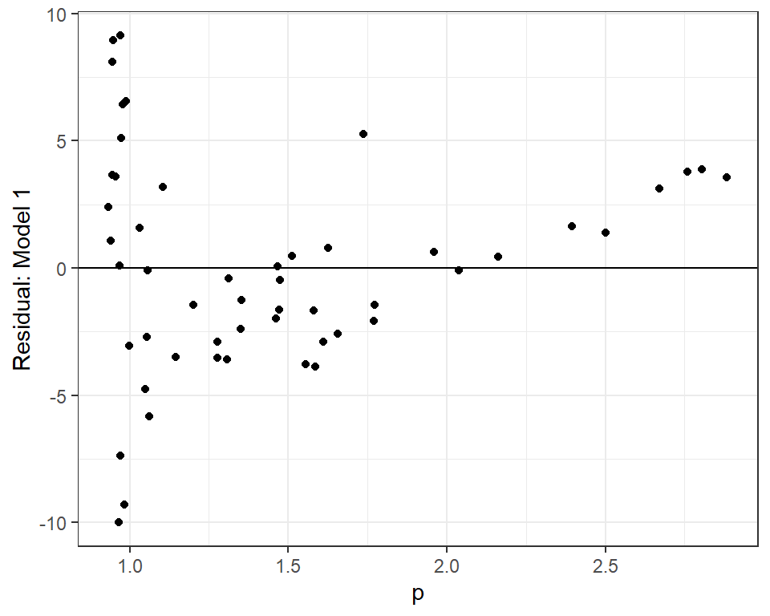

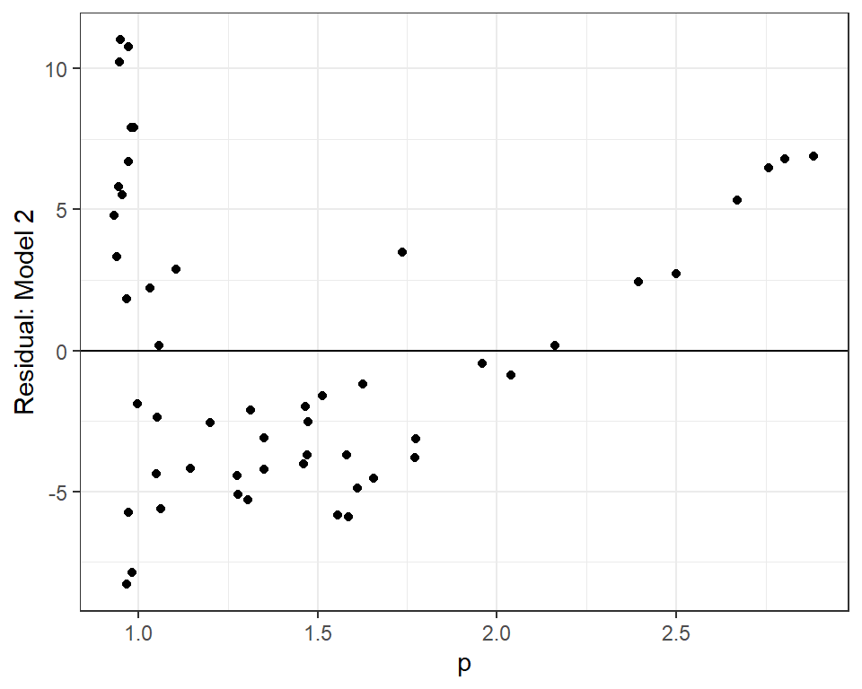

```r
newbroiler$res1 <- resid(m1)
newbroiler$res2 <- resid(m2)

newbroiler |>
  ggplot(aes(x = p, y = res1)) +
  geom_point() +
  geom_hline(yintercept = 0) +
  labs(x = "p", y = "Residual: Model 1") +
  theme_bw()
newbroiler |>
  ggplot(aes(x = p, y = res2)) +
  geom_point() +
  geom_hline(yintercept = 0) +
  labs(x = "p", y = "Residual: Model 2") +
  theme_bw()
```

Remember that a good functional form should leave little systematic structure in the residuals.

## problem 30 — One-picture comparison

Overlay the fitted curves from all four models.

**Question:** Which curve appears to follow the economic pattern most convincingly?

## Solution 30 — R code

**Show R code**

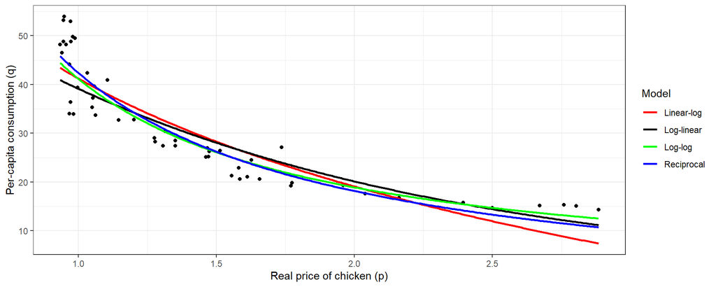

```r
library(tidyverse)
library(mosaic)

# Convert estimated models into functions
f1 <- makeFun(m1)
f2 <- makeFun(m2)
f3 <- makeFun(m3, transformation = exp)
f4 <- makeFun(m4, transformation = exp)

# Generate fitted values
predictions <- tibble(
  p = seq(min(newbroiler$p), max(newbroiler$p), length.out = 300)) |>
  mutate(
     Reciprocal = f1(p),
    `Linear-log` = f2(p),
    `Log-linear` = f3(p),
    `Log-log` = f4(p)) |>

  pivot_longer(cols = -p,names_to = "Model",values_to = "q")

# Plot observed and fitted demand curves
ggplot() +
  geom_point(
    data = newbroiler,
    aes(x = p, y = q)
  ) +
  geom_line(
    data = predictions,
    aes(x = p, y = q, color = Model),
    linewidth = 1
  ) +
  scale_color_manual(
    values = c(
      "Reciprocal" = "blue",
      "Linear-log" = "red",
      "Log-linear" = "black",
      "Log-log" = "green"
    )
  ) +
  labs(
    x = "Real price of chicken (p)",
    y = "Per-capita consumption (q)",
    color = "Model"
  ) +
  theme_bw()
```

**Show R code**

```r
# Alternative to the above
# pgrid <- seq(min(newbroiler$p),max(newbroiler$p),length.out = 300)
# q1grid <- predict(m1,newdata = data.frame(p = pgrid))
# q2grid <- predict(m2,newdata = data.frame(p = pgrid))
# q3grid <- exp(predict( m3,newdata = data.frame(p = pgrid)))
#
# q4grid <- exp(predict( m4,newdata = data.frame(p = pgrid)))
#
# plot(
#   newbroiler$p,
#   newbroiler$q,
#   xlab = "Real price of chicken (p)",
#   ylab = "per-capita consumption (q)"
# )
#
# lines(pgrid, q1grid, lwd = 2)
# lines(pgrid, q2grid, lwd = 2, lty = 2)
# lines(pgrid, q3grid, lwd = 2, lty = 3)
# lines(pgrid, q4grid, lwd = 2, lty = 4)
#
# legend(
#   "topright",
#   legend = c(
#     "Reciprocal",
#     "Linear-log",
#     "Log-linear",
#     "Log-log"
#   ),
#   lty = 1:4,
#   lwd = 2,
#   bty = "n"
# )
```

## Final seminar challenge

Consider the case that your team is the demand-analysis unit at the USDA.

Recommend **one functional form** for describing the chicken price–consumption relationship.

Prepare a **four-sentence recommendation**:

1. Which model do you prefer?
2. What does its marginal effect imply at the median price?
3. What does its elasticity imply at the median price?
4. Why is it preferable to the alternatives?

## Final challenge — Debrief criteria

A strong choice considers:

- coefficient signs and demand theory;
- fitted curve;
- comparable goodness-of-fit;
- residual behavior;
- marginal effect;
- elasticity;
- simplicity and interpretability.

## Chapter 4 principle

> **Choose a functional form by combining economic meaning with statistical evidence.**

## Exit ticket

Without notes, complete the formulas.

### Reciprocal

$$ME=\underline{\hspace{2cm}},
\qquad
\varepsilon=\underline{\hspace{2cm}}$$

### Linear-log

$$ME=\underline{\hspace{2cm}},
\qquad
\varepsilon=\underline{\hspace{2cm}}$$

### Log-linear

$$ME=\underline{\hspace{2cm}},
\qquad
\varepsilon=\underline{\hspace{2cm}}$$

## Exit ticket — Answers

### Reciprocal

$$\boxed{ME=-\frac{\alpha_2}{p^2}}
\qquad
\boxed{\varepsilon=-\frac{\alpha_2}{pq}}$$

### Linear-log

$$\boxed{ME=\frac{\gamma_2}{p}}
\qquad
\boxed{\varepsilon=\frac{\gamma_2}{q}}$$

### Log-linear

$$\boxed{ME=\phi_2q}
\qquad
\boxed{\varepsilon=\phi_2p}$$

## One sentence to remember

> **The coefficient is not automatically the marginal effect, and the marginal effect is not automatically the elasticity.**